# Web Framework Evaluation

Generating tip calculator apps across 4 Python web frameworks with a single LLM prompt

## Prompt & Model

**Generator model:** `claude-sonnet-4-6` via [chatlas](https://posit-dev.github.io/chatlas/) `ChatAnthropic` with `tool_web_search()` enabled

**Evaluator model:** `claude-sonnet-4-6` via [Inspect AI](https://inspect.aisi.org.uk/)

**Prompt given to the LLM to generate each app:**

> Create an app using **{framework}** that is a basic tip calculator which features a clean interface with input fields for the bill amount and tip percentage (with 15%, 18%, or 20% presets). It must instantly calculate and display the tip amount and the total bill (bill + tip), with an optional, useful feature to split the total among multiple people. Do not use extra packages or CSS or JavaScript other than what {framework} already provides.

The `{framework}` placeholder was filled with each of: **Streamlit**, **Plotly Dash**, **Panel**, and **Shiny for Python**.

## Frameworks Generated

| Framework | Directory | Run Command |
| --- | --- | --- |
| Streamlit | `streamlit/` | `streamlit run streamlit/app.py` |
| Plotly Dash | `dash/` | `python dash/app.py` |
| Panel | `panel/` | `panel serve panel/app.py` |
| Shiny for Python | `shiny/` | `shiny run shiny/app.py` |

## Test Scenario

Each app was started, given a bill of **$85.50** with a **20% tip** split among **3 people**.

## Before & After Screenshots

### Streamlit

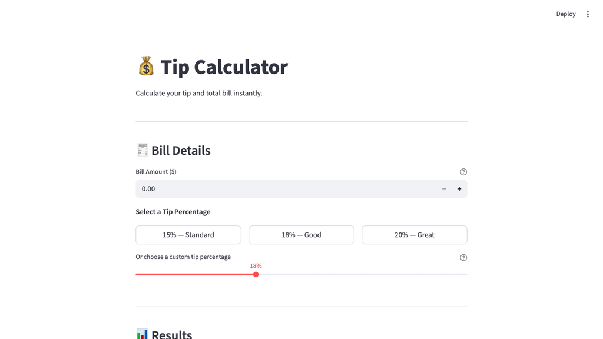

Before

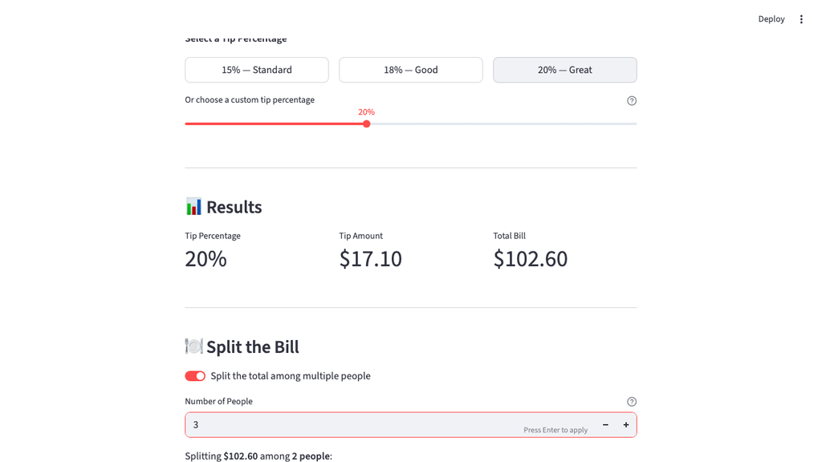

After

### Plotly Dash

[figure not shown]

Before

[figure not shown]

After

### Panel

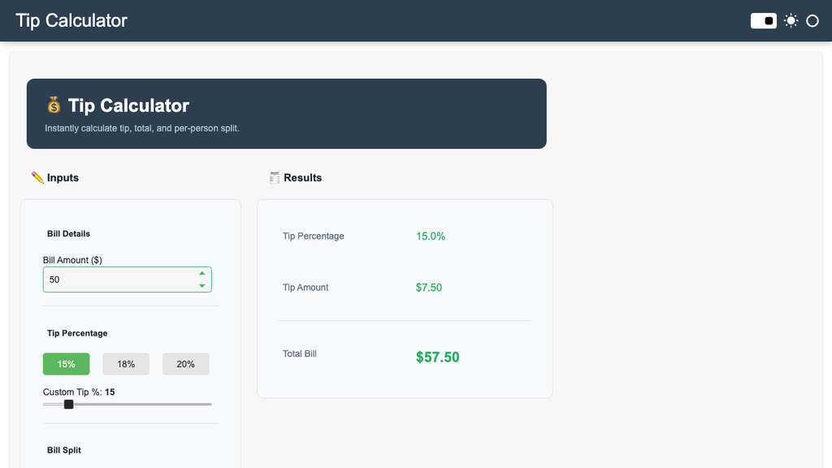

Before

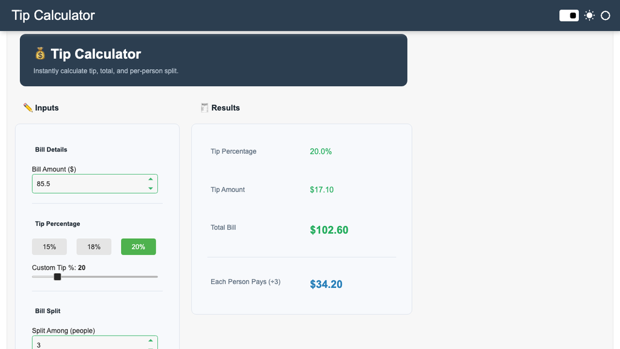

After

### Shiny for Python

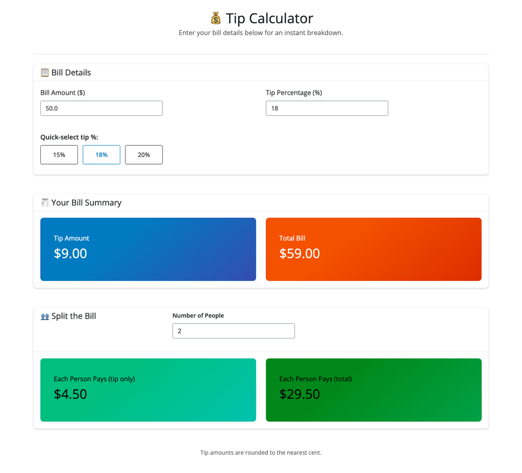

Before

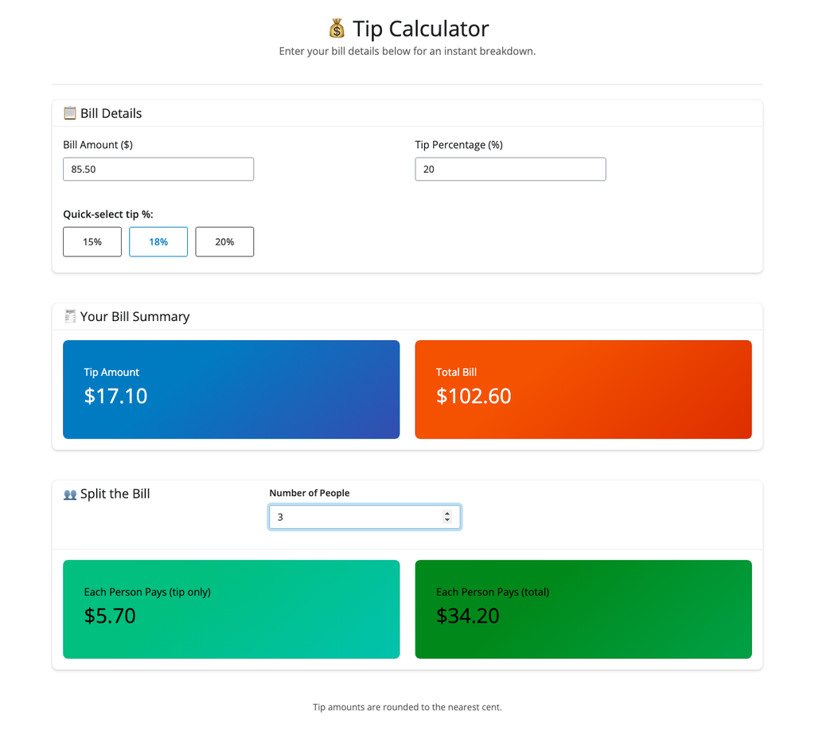

After

## Evaluation with Inspect AI

Each generated app was scored by `claude-sonnet-4-6` (via [Inspect AI](https://inspect.aisi.org.uk/)) on three criteria (1–10 scale). The scorer received the full app source code plus before/after screenshots:

- **Maintainability** – Is the code well-structured, modular, and easy to extend?
- **Readability** – Is it intuitive to read and idiomatic for the framework?
- **Requirement Adherence** – Does it meet every specification and do the screenshots confirm it works?

### Score Summary

| Framework | Maintainability | Readability | Adherence |
| --- | --- | --- | --- |
| Streamlit | 8 | 9 | 7 |
| Plotly Dash | 8 | 8 | 10 |
| Panel | 7 | 7 | 9 |
| Shiny for Python | 9 | 9 | 10 |
| **Mean** | **8.00** | **8.25** | **9.00** |

### Streamlit – Evaluation

I’ll analyze the app code and screenshots across the three criteria.

#### Criterion 1: Maintainability (Score: 8/10)

**Strengths:**

- Code is well-organized with clear section comments using visual separators (`# ──`)
- Logical flow: config → inputs → calculations → outputs → split feature
- Session state is used appropriately for the tip percentage persistence
- Calculations are isolated into simple, clear formulas
- Good use of columns for layout consistency

**Weaknesses:**

- The summary caption at the bottom references `num_people` which could cause a `NameError` if `split_on` is True but the variable is somehow not defined (minor scoping risk)
- No functions/helpers — everything is inline, which makes future refactoring slightly harder
- The “Splitting … among **2 people**” bug (visible in after screenshot) indicates a display logic issue

#### Criterion 2: Readability (Score: 9/10)

**Strengths:**

- Excellent inline comments with clear section headers
- Descriptive variable names (`bill_amount`, `tip_pct`, `per_person_total`, etc.)
- Follows idiomatic Streamlit patterns (session state, columns, metrics)
- Help text on inputs adds to self-documentation
- Logical top-to-bottom flow mirrors the UI layout

**Weaknesses:**

- Minor: the session state sync pattern (setting after slider) is slightly confusing since the buttons set it before and the slider reads it — understandable but not immediately obvious

**Strengths:**

- ✅ Input field for bill amount
- ✅ 15%, 18%, 20% preset buttons are present
- ✅ Custom tip slider also available
- ✅ Instant calculation of tip amount and total bill displayed
- ✅ Bill splitting feature implemented
- ✅ No extra packages, CSS, or JavaScript used
- ✅ Before screenshot confirms clean default state

**Weaknesses:**

- ❌ **Bug confirmed in after screenshot**: “Splitting $102.60 among **2 people**” is shown even though 3 people are entered (the number input shows 3 but the text says 2 — likely a Streamlit re-run/state timing issue where `num_people` lags one interaction)
- The split toggle adds a small UX friction — could default to showing the split section more prominently
- The “20% — Great” button in the after screenshot appears slightly highlighted but there’s no clear visual indicator of the selected preset

### Plotly Dash – Evaluation

I’ll evaluate this Plotly Dash tip calculator app across the three criteria.

#### Criterion 1: Maintainability

**Strengths:**

- Style constants are centralized at the top using named color variables (`PRIMARY`, `CARD_BG`, etc.), making global theme changes easy
- The two callbacks are well-separated by concern (one for syncing presets, one for calculations)
- The layout is logically organized into clearly named sections (Bill Amount, Tip Percentage, Results, Split)
- Style dictionaries use composition (`{**preset_btn_base, ...}`) to reduce duplication
- Good use of constants to avoid magic numbers/strings

**Weaknesses:**

- The large number of style dictionaries (15+) at the module level creates a long file that’s somewhat monolithic — a larger project would benefit from separating styles
- The `sync_preset` callback imports `ctx` inside the function rather than at module level
- Some mild logic duplication in the `btn_style` inner function

**Score: 8/10**

#### Criterion 2: Readability

**Strengths:**

- Excellent use of section comments (`# ── Bill Amount ──...`) that visually separate layout blocks
- Variable names are descriptive and self-documenting (`bill_err`, `tip_amount`, `per_person_str`)
- The `preset_map` dictionary elegantly maps button IDs to values
- The file-level comment “Tip Calculator — Plotly Dash App” and section headers guide readers well
- Callback logic is clean and follows a clear validate-then-compute pattern

**Weaknesses:**

- The density of style dictionaries near the top is visually overwhelming and may slow down reading the actual app logic
- Minor: `from dash import ctx` inside the callback is unconventional and could confuse readers expecting all imports at the top

**Score: 8/10**

#### Criterion 3: Requirement Adherence

**Strengths:**

- ✅ Input field for bill amount with proper number input
- ✅ Input field for tip percentage (custom)
- ✅ All three preset buttons (15%, 18%, 20%) present and functional
- ✅ Active preset button highlights correctly (20% shown filled/blue in “after” screenshot)
- ✅ Instant calculation — tip amount ($17.10) and total bill ($102.60) shown correctly for $85.50 @ 20%
- ✅ Split among multiple people works correctly ($102.60 ÷ 3 = $34.20 confirmed in screenshot)
- ✅ No external CSS files, JS files, or extra packages used — only Dash’s built-in inline styles
- ✅ Input validation with error messages for edge cases
- ✅ Clean, professional interface

**Weaknesses:**

- Essentially none — all requirements are fully met and verified by screenshots

**Score: 10/10**

### Panel – Evaluation

I’ll evaluate this Panel tip calculator app on three criteria.

#### Criterion 1: Maintainability (Score: 7/10)

**Strengths:**

- The code is well-organized into logical sections (color palette, widgets, callbacks, result pane, layout) with clear section comments using `──` separators
- The `_result_card` function centralizes all calculation logic cleanly
- The `_update_presets` helper avoids repetition across the three preset callbacks
- The `row()` inner function inside `_result_card` is a nice reusable pattern for result rows
- Color constants are defined at the top, making theme changes easy

**Weaknesses:**

- The large color palette block (12+ constants) at the top is somewhat verbose and could be a dict or dataclass
- Inline HTML strings with embedded f-strings for styling make future modifications tedious
- `section_label` as a lambda is slightly unconventional (lambdas aren’t ideal for reusable UI components)
- The layout nesting is fairly deep, which could complicate future restructuring

#### Criterion 2: Readability (Score: 7/10)

**Strengths:**

- Section headers with `──` delimiters make it easy to navigate
- Function names are descriptive (`on_preset_15`, `_update_presets`, `_result_card`)
- The `pn.bind` reactive pattern is idiomatic Panel
- Logic flow is easy to follow top-to-bottom

**Weaknesses:**

- No docstrings or comments explaining the calculation logic (though it’s simple math)
- Heavy use of inline HTML/CSS strings within Python reduces readability
- The `_result_card` function is fairly long and mixes layout construction with business logic
- Color constant names like `CLR_PRESET_TXT_ON` and `CLR_PRESET_TXT_OFF` are defined but never actually used in the code

#### Criterion 3: Requirement Adherence (Score: 9/10)

**Strengths:**

- ✅ Input field for bill amount (FloatInput)
- ✅ Tip percentage input with slider
- ✅ All three presets (15%, 18%, 20%) implemented as buttons with visual highlighting
- ✅ Instant calculation via `pn.bind` — tip amount and total bill displayed reactively
- ✅ Bill splitting feature works correctly (÷3 shown in after screenshot)
- ✅ Screenshots confirm correct math: $85.50 × 20% = $17.10 tip, $102.60 total, $34.20 per person
- ✅ No extra packages beyond Panel used
- ✅ Preset button highlighting updates correctly (20% shown as green in after screenshot)

### Shiny for Python – Evaluation

I’ll evaluate this Shiny for Python tip calculator app on the three criteria.

#### Criterion 1: Maintainability (Score: 9/10)

**Strengths:**

- Well-structured separation between UI and server logic with clear section comments
- Single `calc()` reactive that centralizes all computation — easy to modify formulas in one place
- Logical grouping of UI elements into cards (inputs, results, split)
- Preset button handlers are clean and consistent (three separate `@reactive.effect` handlers)
- Good use of `max(int(...), 1)` guard to prevent division by zero
- Named outputs are clearly mapped to their display elements

**Minor concerns:**

- The three preset handlers are slightly repetitive; a helper function could reduce boilerplate, but at this scale it’s acceptable
- The `calc()` dictionary approach works but a dataclass/namedtuple would be more maintainable at larger scale

#### Criterion 2: Readability (Score: 9/10)

**Strengths:**

- Excellent use of section comments (`# ── Header ──`, `# ── Server ──`, etc.) for visual scanning
- Variable names (`bill`, `tip_pct`, `num_people`, `per_person_tip`) are highly descriptive
- Follows idiomatic Shiny for Python patterns (`@reactive.calc`, `@render.text`, `@reactive.effect`)
- The UI structure mirrors what the user sees, making it easy to map code to visual output
- Arithmetic is straightforward and easy to follow

**Minor concerns:**

- `_apply_15`, `_apply_18`, `_apply_20` private naming convention is fine but the underscore prefix may confuse some readers
- A brief comment explaining the `or 0.0` / `or 1` fallback pattern would help

#### Criterion 3: Requirement Adherence (Score: 10/10)

**Strengths:**

- ✅ Input field for bill amount (numeric, default $50, step $0.01)
- ✅ Input field for tip percentage (numeric, editable)
- ✅ All three presets present: 15%, 18%, 20% as action buttons
- ✅ Instant calculation (reactive, no submit button needed)
- ✅ Displays tip amount ($17.10 for $85.50 × 20% ✓)
- ✅ Displays total bill ($102.60 = $85.50 + $17.10 ✓)
- ✅ Bill splitting among N people ($34.20 = $102.60 ÷ 3 ✓)
- ✅ No external CSS, JavaScript, or extra packages used
- ✅ Screenshots confirm correct calculations for the test case
- The bonus “split tip only” per person is a nice addition

All calculations verified against the after screenshot are mathematically correct.